# Bird and Mammal Census Kaggle

AOC

4/25/2022

## Mammal and Bird Census Data Visualization

This project uses a public mammal and bird census dataset that can be found at https://www.kaggle.com/datasets/jishnukoliyadan/bird-and-mammal-census-calcofi-nmfs-cpr and originally at https://portal.edirepository.org/nis/mapbrowse?packageid=knb-lter-cce.255.3. I want to thank the organizations and personnel responsible for providing the data publicly.

Farallon Institute Advanced Ecosystem Research, CalCOFI - Scripps Institution of Oceanography, California Current Ecosystem LTER, and B. Sydeman. 2021. Bird and mammal observations aboard CalCOFI (1987-2021, ongoing), NMFS (1996-2021, ongoing) and CPR (2003-2006, completed) cruises. ver 3. Environmental Data Initiative. https://doi.org/10.6073/pasta/4ee1bd702acb11786277192a41626800 (Accessed 2022-05-19)

My immediate interest is just to explore the data and practice visualization, first for depth comparison of aquatic mammals and then a little mapping with leaflet. I might make a model along the way.

```r
library(data.table)
library(dplyr)
library(ggplot2)
library(readxl)
library(stringr)
library(devtools)
library(ggpubr)
```

## Reading in the data

```r
cpr_obs <- fread('CPR_cruise_observations.csv')
spec_codes <- read_excel('species_codes.xlsx')
cpr_transect <- fread('CPR_cruise_transect_log.csv')
nmfs_obs <- fread('NMFS_cruise_observations.csv')
nmfs_transect <- fread('NMFS_cruise_transect_log.csv')

nmfs_obs$Species <- str_trim(nmfs_obs$Species, 'right')

spec_codes$Species <- str_trim(spec_codes$Species, 'right')

# head(cpr_transect)

data <- left_join(nmfs_obs, nmfs_transect, by='GIS key')
data$Species <- str_trim(data$Species, 'right')

newdata <- left_join(data, spec_codes, by = "Species")
```

Now that we’re all joined up, I want to pull out my whale species and plot them by depth to see if we see anything interesting.

```r
list <- newdata %>%
  group_by(Definition) %>%
  summarize(n=n(), depth = mean(`Depth (m)`))
list
```

```
## # A tibble: 58 x 3
##    Definition                                           n depth
##    <chr>                                            <int> <dbl>
##  1 Ancient Murrelet                                     6    NA
##  2 Arctic Tern                                         38    NA
##  3 Ashy Storm-Petrel                                  154    NA
##  4 Bairds beaked whale or Blainville's beaked whale     3    NA
##  5 Black-footed Albatross                            4941    NA
##  6 Black-legged Kittiwake                              28    NA
##  7 Black-vented Shearwater                             18    NA
##  8 Blue whale                                         108    NA
##  9 Bonaparte                                          113    NA
## 10 Bottlenose dolphin                                   9    NA
## # ... with 48 more rows
```

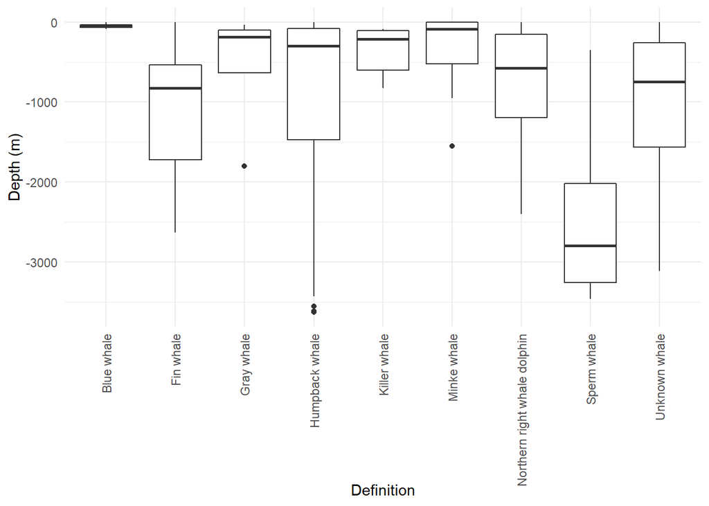

```r
whales <- newdata %>%
  filter(grepl('whale', Definition))

#glimpse(whales)

whales_depth <- whales %>%
  filter(is.na(`Depth (m)`) == FALSE)

#glimpse(whales_depth)

whale_depth_box <- ggplot(data = whales_depth, aes(x=Definition,y = `Depth (m)`)) +
  geom_boxplot() +
  theme_minimal() +
  theme(axis.text.x = element_text(angle = 90, vjust = 0.5, hjust=1),legend.position = "None")

whale_depth_box
```

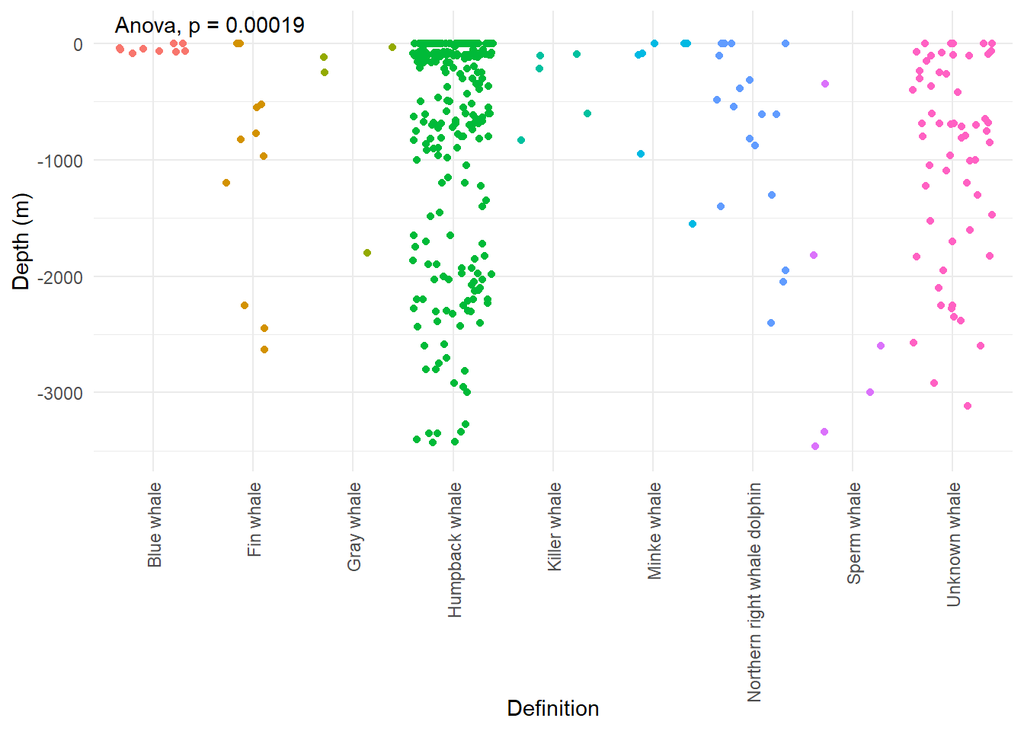

```r
whale_depth_jit <- ggplot(data = whales_depth, aes(x=Definition, y = `Depth (m)`, color=Definition)) +
  geom_jitter() +
  theme_minimal() +
  ylim(-3500, 100) +
  theme(axis.text.x = element_text(angle = 90, vjust = 0.5, hjust=1),legend.position = "None") +
  stat_compare_means(method ="anova")

whale_depth_jit
```

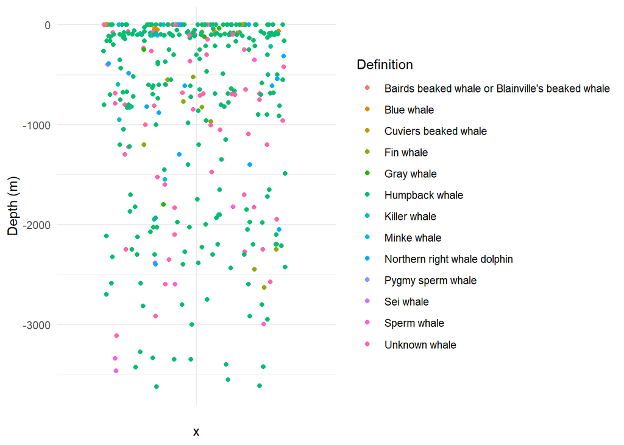

```r
whales$x <- ''

whale_depth_jit2 <- ggplot(data = whales, aes(x=x, y=`Depth (m)`, color=Definition)) +
  geom_jitter() +
  theme(axis.text.x = element_text(angle = 90, vjust = 0.5, hjust=1)) +
  theme_minimal()

whale_depth_jit2
```

Some obvious depth sighting differences show up. You never see sperm whales near the top, although you don’t see many at all, and many whales don’t get noticed nearly as far down as some others.

## Mapping with Leaflet

I’m not an expert with mapping data visualization, but I did a little tutorial which pulled earthquake data and put it in leaflet a while back and loved what I could produce quickly and easily. Find the tutorial here https://towardsdatascience.com/how-to-make-stunning-geomaps-in-r-a-complete-guide-with-leaflet-be1b857f1644. Here I take the same whale data and use the middle latitude and longitudes of the arc of data that was recorded and mapped it over the coast of California where the census cruises took place.

```r
library(leaflet)
library(rgdal)

whales <- whales %>%
  rename(longitude=`Longitude Mid (Âº)`) %>%
  rename(latitude=`Latitude Mid (Âº)`)

factpal <- colorFactor(topo.colors(5), whales$Definition)

leaflet() %>%
  setView(lng = -121, lat = 36, zoom = 5) %>%
  addProviderTiles("Esri.WorldStreetMap") %>%
  addCircles(
    data = whales,
    radius = 5,
    color = ~factpal(Definition),
    fillColor = "#F60D1D",
    fillOpacity = 0.25,
    popup = paste0(
      "<strong>Time: </strong>", whales$Date, "<br>",
      "<strong>Time: </strong>", whales$Definition, "<br>",
      "<strong>Time: </strong>", whales$Season, "<br>"
    )
  )
```

[interactive chart not shown]